# Analysis on NFL Offensive Strategy

December 19, 2019

## Introduction

- Datasets (2010-2013 NFL Season)
  - Main Dataset: Basic Game and Play Dataset (2010-2013) = 177739 obs, 18 var
  - Auxiliary 1: Detailed Play-by-Play Data = 166599 obs, 102 var
  - Auxiliary 2: Game Day Weather Data = 841 obs, 12 var
  - Auxiliary 3: Game Day Attendance Data = 128 obs, 22 var
- Application
  - NFL far behind other leagues as far as sports analytics - eye-test
  - What truly affects a team’s ability to win a game?
- Investigation
  - Super Bowl XLVI - Mario Manningham

## Effect of Game Conditions on Play Type

## Game Condition Analysis

- I analyzed the effect of a few factors on the distribution of play types in NFL games.
- Play Types [Categories]
  - No Play (Penalties)
  - Kick
  - Pass
  - Run
- Game Condition Variables [Explanatory]
  - Yards to First Down
  - Number of Downs
  - Score Difference
  - Time in Game
- Proportional Distribution of Play Types [Response]

## Number of Downs and Yards to First Down

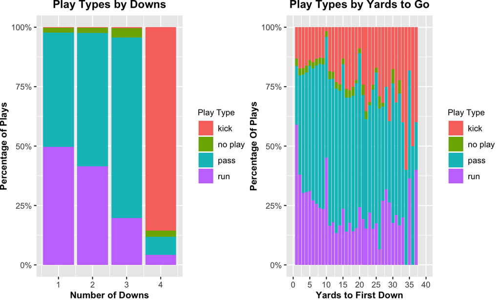

- As teams have more downs, they pass the ball more (with the obvious exception of 4th Down)
- As teams get closer to first down, they run the ball more

## Score Difference

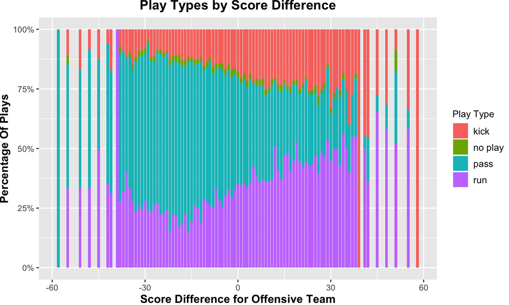

- As teams gain a bigger lead over their opponents, they run the ball more and pass the ball less.

## Time

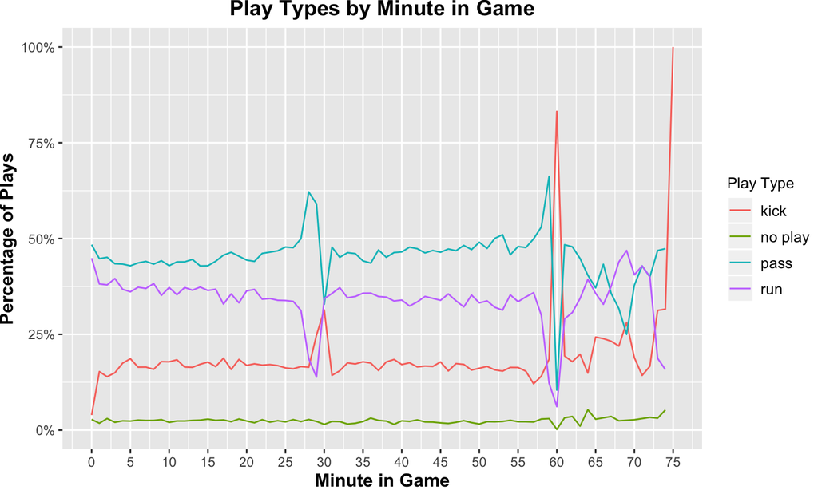

- Passes increase around the 30 minute and 60 minute mark because teams are trying to score quickly before the period ends.

## Effect of Weather Conditions on Play Type

## Weather Condition Analysis

- I analyzed the effect of weather factors on the distribution of play types in NFL games.
- Play Types [Categories]
  - No Play (Penalties)
  - Kick
  - Pass
  - Run
- Weather Condition Variables [Explanatory]
  - Temperature
  - Humidity
  - Wind Speeds
- Proportional Distribution of Play Types [Response]

## Effect of Weather Conditions on Play Type

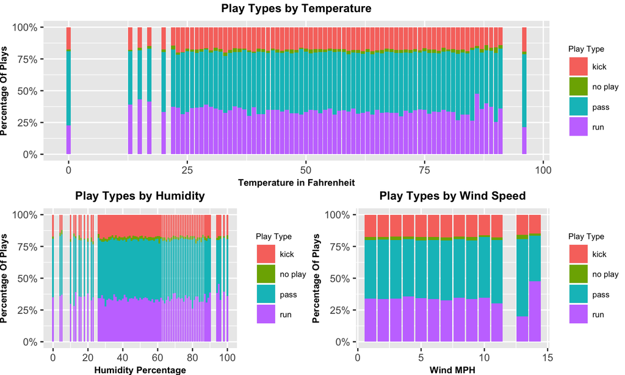

- Does not seem to be any correlation between weather factors and play type distribution.

## Multiple Regression on Proportion of Pass Plays

|  | Estimate | SE | t | p.value |
| --- | --- | --- | --- | --- |
| (Intercept) | 0.4330754 | 0.0134529 | 32.1918638 | 0.0000000 |
| temperature | 0.0005555 | 0.0001655 | 3.3559611 | 0.0008764 |
| humidity | 0.0000117 | 0.0001346 | 0.0866876 | 0.9309687 |
| wind_mph | -0.0007561 | 0.0008627 | -0.8764553 | 0.3813752 |

- Temperature variable is statistically significant.

## Multiple Regression on Proportion of Run Plays

|  | Estimate | SE | t | p.value |
| --- | --- | --- | --- | --- |
| (Intercept) | 0.3722100 | 0.0134950 | 27.5813431 | 0.0000000 |
| temperature | -0.0006124 | 0.0001660 | -3.6881868 | 0.0002612 |
| humidity | 0.0000144 | 0.0001350 | 0.1065917 | 0.9151731 |
| wind_mph | 0.0005647 | 0.0008654 | 0.6525030 | 0.5144990 |

- Temperature variable is statistically significant.

## Simple Regression: Effect of Home Attendance

|  | Estimate | SE | t | p.value |
| --- | --- | --- | --- | --- |
| (Intercept) | 4.1276090 | 0.1722258 | 23.966261 | 0e+00 |
| y=Yards Gained | 0.0000127 | 0.0000025 | 5.010491 | 5e-07 |

|  | Estimate | SE | t | p.value |
| --- | --- | --- | --- | --- |
| (Intercept) | 3.2576000 | 0.1559522 | 20.888455 | 0.0000000 |
| y=Air Yards | 0.0000085 | 0.0000023 | 3.696993 | 0.0002182 |

|  | Estimate | SE | t | p.value |
| --- | --- | --- | --- | --- |
| (Intercept) | 0.5423698 | 0.0105461 | 51.428587 | 0.0000000 |
| y=Pass Proportion | 0.0000005 | 0.0000002 | 3.301096 | 0.0009633 |

## Success of Runs vs Passes

## Hypothesis Testing

- Conventional Wisdom: Pass plays have more potential and run plays are safer
- Null Hypothesis: E[yards gained|pass] = E[yards gained|run]
- Alternative Hypothesis: E[yards gained|pass] > E[yards gained|run]
  - Sample Mean Yards Gained When Passing = 6.3659
  - Sample Mean Yards Gained When Running = 3.9691
  - Degrees of Freedom: 138970
  - t = 37.992
  - p-value = < 2.2e-16
- The null hypothesis is rejected, confirming the Alternative Hypothesis.

## Why Do Teams Run?

| Yards to First Down | P(First Down\|pass) | P(First Down\|run) |
| --- | --- | --- |
| 1 | 0.5703578 | 0.7884335 |
| 2 | 0.5577488 | 0.6757969 |
| 3 | 0.5399470 | 0.5521009 |
| 4 | 0.5177621 | 0.4356282 |
| 5 | 0.4883518 | 0.3431815 |
| 6 | 0.4378047 | 0.2681428 |
| 7 | 0.3991520 | 0.2159858 |
| 8 | 0.3619126 | 0.1776701 |
| 9 | 0.3270712 | 0.1470714 |
| 10 | 0.2895619 | 0.1194114 |

- Running the ball has a higher success rate for a shorter amount of yards.

## Simulation

## Super Bowl XLVI - 38-Yd Manningham Catch

[interactive chart not shown]

## Simulation Explanation

- 5 Linear Models:
  - Probability that a Play is a Pass or Run Play
  - Pass Completion Percentage
  - Expected Air Yards from a Pass Play
  - Expected Yards Gained from a Pass Play
  - Expected Yards Gained from a Run Play
- 3 Situations Explored
  - What would’ve happened had the Giants not completed the 38-yard pass?
  - What else could the Giants have done after the completed 38-yard pass?
  - What could have happened if the 38-yard pass was never attempted?

## Simulation Models

|  | Score.Difference | Yards.Until.1st.Down | Down | Time | Yardline | Giants | Temperature |
| --- | --- | --- | --- | --- | --- | --- | --- |
| Pass Probability | Yes | Yes | Yes | Yes | No | Yes | Yes |
| Air Yards | No | Yes | No | Yes | No | Yes | No |
| Completion Probability | Yes | Yes | Yes | Yes | No | Yes | Yes |
| Pass Yards Gained | Yes | Yes | Yes | No | No | No | No |
| Run Yards Gained | Yes | Yes | Yes | Yes | Yes | No | Yes |

## Simulation - Risky Pass was Incomplete

46.5% Touchdown Rate on 1000 trials…one example simulation shown

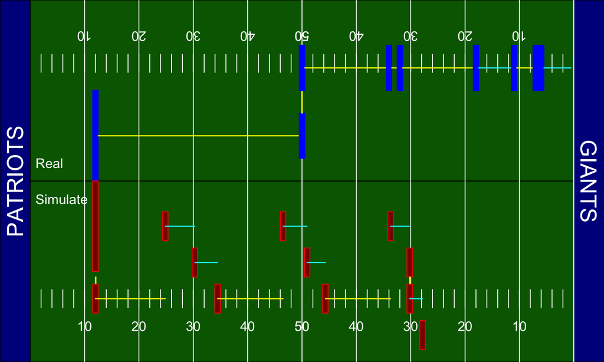

## Simulation - Risky Pass is Complete

61.3% Touchdown Rate on 1000 trials…one example simulation shown

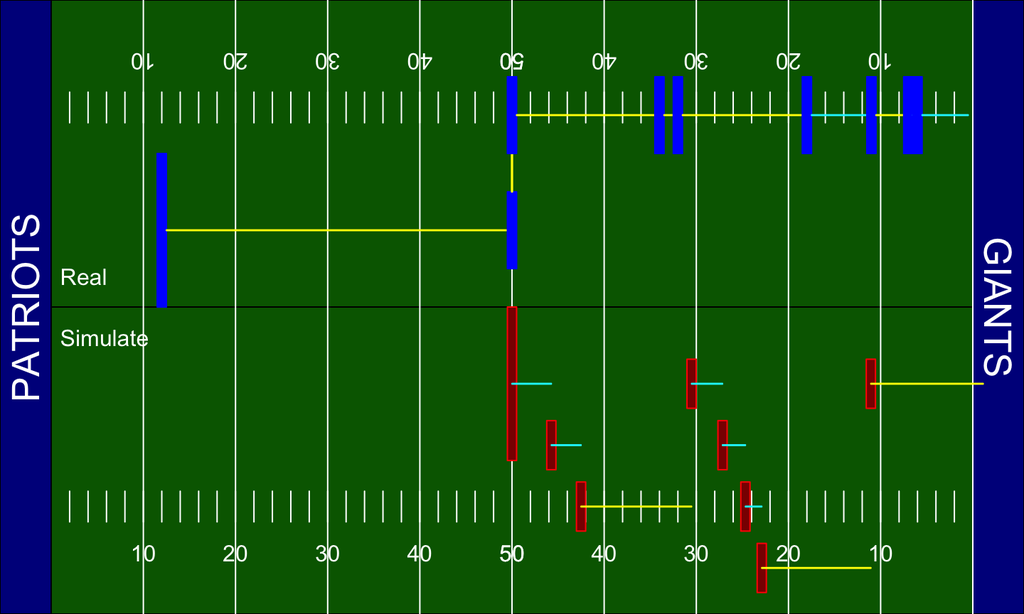

## Simulation - Computer-Selected First Play

50.8% Touchdown Rate on 1000 trials…one example simulation shown

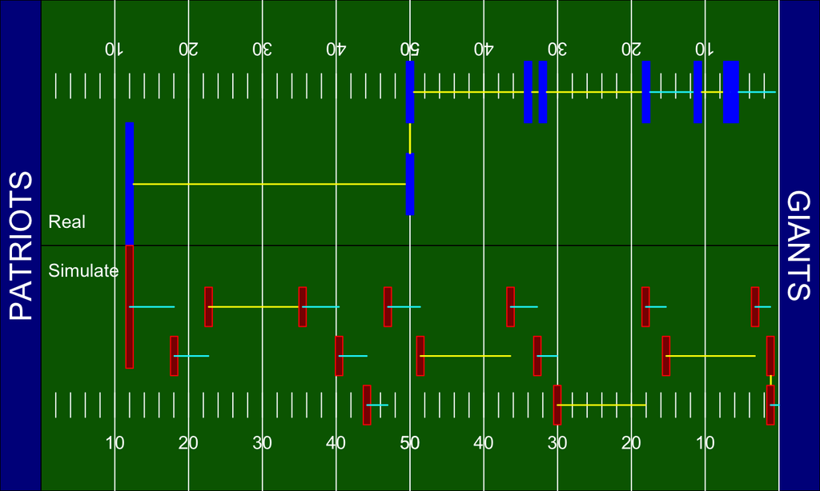

## Conclusion

- From the Pass Completion Model: Probability of completing risky play to Manningham = 32.1%
- From the simulations:
  - Probability of scoring TD given risky play was attempted: 0.321 x 0.613 + 0.679 x 0.465 = 51.3%
  - Probability of scoring TD when simulation chooses first play: 50.8%
  - T-test tells us that the difference between these two percentages is not statistically significant.
    - p-value = 0.59
- Verdict:
  - Decision to call the risky 38-yard pass to Manningham did not significantly improve or reduce Giants’ chances of winning Super Bowl